# Iran 2005 election and possible random effect

2022-07-18

In Iran’s 2005 Presidential elections, the results were, more than anything else, unexpected. Ahmadinejad, then mayor of Tehran, was a marginal figure even a week before the elections, ranking last or penultimate in most polls. Then something changed. His victory shocked pundits and politicians alike, resulting in a lot of unfounded ‘explanations’ for his victory. Barely any quantitative research has been done into this result. In my research I look at how it happened.

so, here we start with looking at the relationship between urban vote and Ahmadinejad’s votes in the first round of the elections. The variable ‘urban’ is calculated on the basis of Iran’s 2006 national census and the numbers it reported for rural and urban residents of each county. Election results were published at the county-level(شهرستان), and didn’t get more detailed than that.

```r
modelin<-lm(Ahpct~urban, data = elec84)
summary(modelin)
```

```
##
## Call:
## lm(formula = Ahpct ~ urban, data = elec84)
##
## Residuals:
##      Min       1Q   Median       3Q      Max
## -0.22025 -0.07418 -0.02603  0.05096  0.39032
##
## Coefficients:
##             Estimate Std. Error t value Pr(>|t|)
## (Intercept)  0.01330    0.01728   0.770    0.442
## urban        0.25992    0.03076   8.451    1e-15 ***
## ---
## Signif. codes:  0 '***' 0.001 '**' 0.01 '*' 0.05 '.' 0.1 ' ' 1
##
## Residual standard error: 0.109 on 323 degrees of freedom
## Multiple R-squared:  0.1811, Adjusted R-squared:  0.1785
## F-statistic: 71.42 on 1 and 323 DF,  p-value: 1.003e-15
```

Adding the chart here.

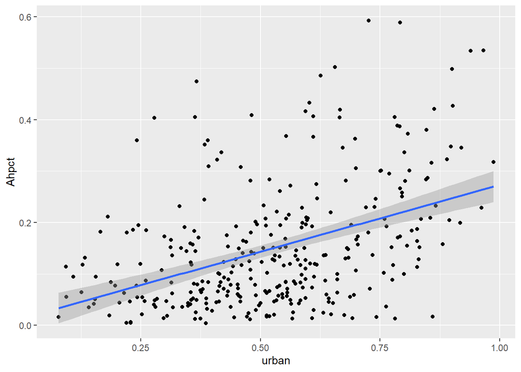

But before that, let’s see if this story holds inside the provinces.

First, I plot the relationship inside each province. Not great, but could be useful.

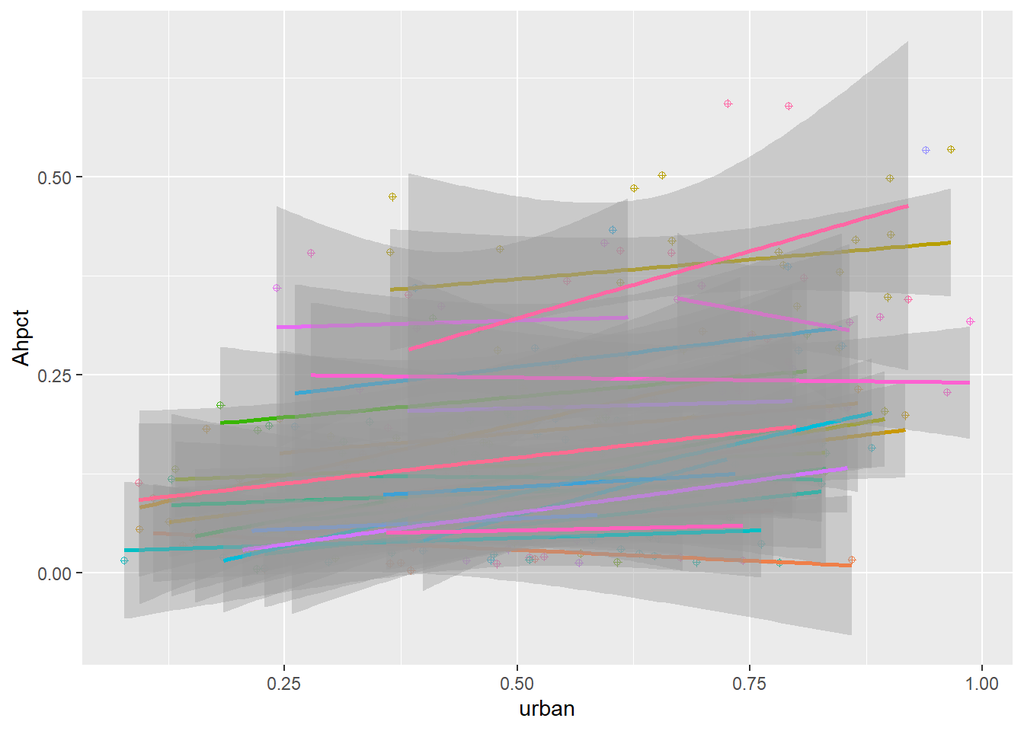

Now let’s do an actual random effects regression

```
## boundary (singular) fit: see help('isSingular')
```

```
## Linear mixed model fit by REML ['lmerMod']
## Formula: Ahpct ~ 1 + urban + (1 + urban | prov)
##    Data: elec84
##
## REML criterion at convergence: -777.9
##
## Scaled residuals:
##     Min      1Q  Median      3Q     Max
## -3.5568 -0.6295 -0.0864  0.5364  3.5672
##
## Random effects:
##  Groups   Name        Variance  Std.Dev. Corr
##  prov     (Intercept) 0.0076839 0.08766
##           urban       0.0005527 0.02351  1.00
##  Residual             0.0038418 0.06198
## Number of obs: 325, groups:  prov, 30
##
## Fixed effects:
##             Estimate Std. Error t value
## (Intercept)  0.09275    0.01946   4.766
## urban        0.12676    0.02014   6.295
##
## Correlation of Fixed Effects:
##       (Intr)
## urban -0.342
## optimizer (nloptwrap) convergence code: 0 (OK)
## boundary (singular) fit: see help('isSingular')
```

and now let’s plot this multilevel plot and see how it goes.

```
##         (Intercept)     urban
## ard     0.018526006 0.1068589
## blch   -0.001348774 0.1015287
## bshr    0.108148765 0.1308946
## chml    0.111836138 0.1318835
## eastaz  0.059905154 0.1179563
## esf     0.266236569 0.1732919
## fars    0.059942879 0.1179664
## gil     0.078627224 0.1229773
## gls     0.027378540 0.1092330
## hmd     0.149804121 0.1420661
## hmz     0.055995911 0.1169079
## ilam    0.040517390 0.1127567
## khgl    0.053062386 0.1161211
## khz     0.050044792 0.1153118
## kmsh    0.011350286 0.1049344
## krd    -0.002343043 0.1012621
## krm     0.048496704 0.1148967
## lor     0.030110609 0.1099657
## mrk     0.180700585 0.1503521
## mzn     0.051625633 0.1157358
## nkhor   0.023431344 0.1081744
## qom     0.287753790 0.1790625
## qzv     0.125315612 0.1354986
## rkhor   0.024020557 0.1083325
## skhor   0.234274761 0.1647201
## smn     0.202848870 0.1562920
## teh     0.143341410 0.1403329
## westaz  0.001603779 0.1023205
## yzd     0.257361738 0.1709117
## znj     0.083876743 0.1243852
```

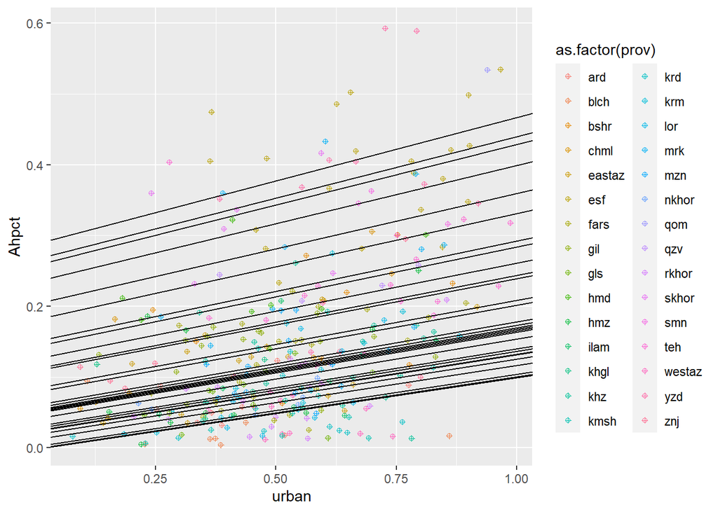